# Is Brainrot also Bodyrot?

## About This Data Story

Every day for several weeks, I logged three things: how many hours I spent on social media, what type of exercise I did, and how long I exercised for. This story explores what that data reveals about my daily habits.

## Which Activity do I spend most time on?

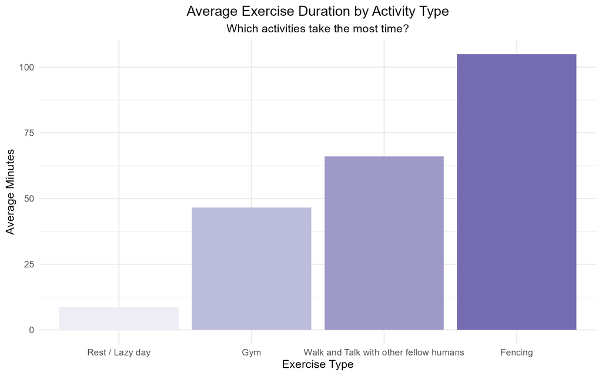

Bar chart showing average exercise duration by activity type.

## Does Screen Time Affect Exercise Time?

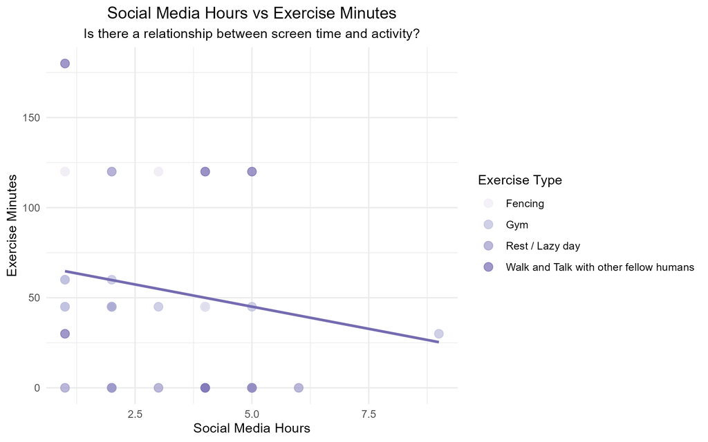

Scatter plot of social media hours vs exercise minutes.

The trend line shows a slight negative relationship — on days with more social media use, exercise minutes tend to be lower. However the pattern is not strong, probably suggesting that I have a set amount of free time which is either spent being active or not.

## How Did Habits Change Over Time?

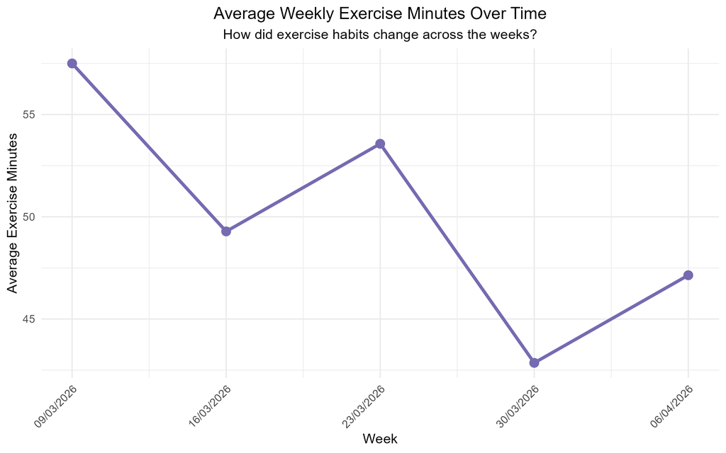

Line chart of average weekly exercise minutes.

Exercise was fairly consistent across the first few weeks, hovering between 47 and 58 minutes on average per day. The dip in the week of 30/03 suggests a less active period, possibly due to some uni projects due all in the same week!No habit formation was observed, there is no definitive trend to suggest consolidation of certain active or inactive habits over time.